# Amazing Document

Amazing Location

Author

Filippo Gambarota

Published

July 8, 2024

# 1 Quarto

## 1.1 General Markup

You can write standard markdown code. Using **bold**, *italic* or underlined text. You can include an external figure and also using cross reference with `@fig-quarto` that produce Figure 1

[figure not shown]

Figure 1: My beautiful caption

## 1.2 Math

You can write math using Latex code:

```latex
$$
y = \beta_0 + \beta_1 + \epsilon
$$
```

$$y = \beta_0 + \beta_1 + \epsilon$$

And also inline math using `$\alpha$` that produce $\alpha$

## 1.3 Citations

You can cite references from a `.bib` file using the syntax `[@Chen2021-jb]` that produce (Chen et al. 2021). We can also cite multiple authors `[@Morey2011-zc; @Lakens2018-ri]` (Morey and Rouder 2011; Lakens, Scheel, and Isager 2018) or suppress the author name `[-@Valentine2011-yq]` (2011).

A reference section will be automatically created at the end of the document (see Section 1.8).

This is the result:

```r
dat <- iris
summary(iris)
```

```
  Sepal.Length    Sepal.Width     Petal.Length    Petal.Width
 Min.   :4.300   Min.   :2.000   Min.   :1.000   Min.   :0.100
 1st Qu.:5.100   1st Qu.:2.800   1st Qu.:1.600   1st Qu.:0.300
 Median :5.800   Median :3.000   Median :4.350   Median :1.300
 Mean   :5.843   Mean   :3.057   Mean   :3.758   Mean   :1.199
 3rd Qu.:6.400   3rd Qu.:3.300   3rd Qu.:5.100   3rd Qu.:1.800
 Max.   :7.900   Max.   :4.400   Max.   :6.900   Max.   :2.500
       Species
 setosa    :50
 versicolor:50
 virginica :50
```

## 1.4 Code chunks - Plots

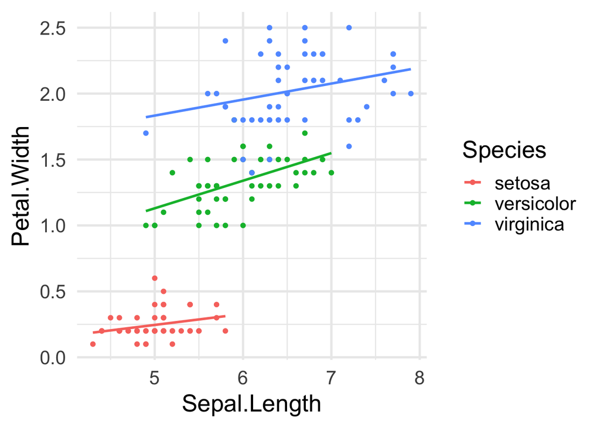

```r
library(ggplot2)
dat |>
    ggplot(aes(x = Sepal.Length, y = Petal.Width, color = Species)) +
    geom_point() +
    geom_smooth(method = "lm", se = FALSE) +
    theme_minimal(20)
```

[figure not shown]

## 1.5 Code chunks - Tables

You can also create already formatted tables with the statistics. Let’s fit a simple linear model:

```r
fit <- lm(Petal.Width ~ Sepal.Length * Species, data = dat)
summary(fit)
```

```
Call:
lm(formula = Petal.Width ~ Sepal.Length * Species, data = dat)

Residuals:
     Min       1Q   Median       3Q      Max
-0.56675 -0.10596 -0.02419  0.09624  0.50897

Coefficients:
                               Estimate Std. Error t value Pr(>|t|)
(Intercept)                    -0.17022    0.38833  -0.438  0.66180
Sepal.Length                    0.08314    0.07739   1.074  0.28444
Speciesversicolor               0.25348    0.49994   0.507  0.61292
Speciesvirginica                1.39633    0.48104   2.903  0.00428 **
Sepal.Length:Speciesversicolor  0.12621    0.09371   1.347  0.18014
Sepal.Length:Speciesvirginica   0.03827    0.08848   0.433  0.66599
---
Signif. codes:  0 '***' 0.001 '**' 0.01 '*' 0.05 '.' 0.1 ' ' 1

Residual standard error: 0.1909 on 144 degrees of freedom
Multiple R-squared:  0.9394,    Adjusted R-squared:  0.9372
F-statistic: 446.1 on 5 and 144 DF,  p-value: < 2.2e-16
```

## 1.6 Code chunks - Tables

```r
library(flextable)
library(broom)

fit |>
    broom::tidy() |>
    flextable() |>
    autofit() |>
    theme_booktabs()
```

My caption

| term | estimate | std.error | statistic | p.value |
| --- | --- | --- | --- | --- |
| (Intercept) | -0.17022108 | 0.38833483 | -0.4383359 | 0.661799706 |
| Sepal.Length | 0.08314444 | 0.07738610 | 1.0744106 | 0.284435724 |
| Speciesversicolor | 0.25347680 | 0.49993857 | 0.5070159 | 0.612919207 |
| Speciesvirginica | 1.39632946 | 0.48104236 | 2.9027162 | 0.004281915 |
| Sepal.Length:Speciesversicolor | 0.12621275 | 0.09370888 | 1.3468601 | 0.180141151 |
| Sepal.Length:Speciesvirginica | 0.03827201 | 0.08848065 | 0.4325467 | 0.665991191 |

## 1.7 Inline code chunks

If you want to use R code within the text to report statistics you can use the syntax `` `r r code` ``. For example:

- the average `Sepal.Length` for the `Setosa` group is `` `r mean(iris$Sepal.Length[iris$Species == 'setosa'])` ``

Become

- the average `Sepal.Length` for the `Setosa` group is 5.006

## 1.8 References

Go back to Section 1.3

## References

Chen, Gang, Daniel S Pine, Melissa A Brotman, Ashley R Smith, Robert W Cox, and Simone P Haller. 2021. “Trial and Error: A Hierarchical Modeling Approach to Test-Retest Reliability.” *NeuroImage* 245 (December): 118647. https://doi.org/10.1016/j.neuroimage.2021.118647.

Lakens, Daniël, Anne M Scheel, and Peder M Isager. 2018. “Equivalence Testing for Psychological Research: A Tutorial.” *Adv. Methods Pract. Psychol. Sci.* 1 (2): 259–69. https://doi.org/10.1177/2515245918770963.

Morey, Richard D, and Jeffrey N Rouder. 2011. “Bayes Factor Approaches for Testing Interval Null Hypotheses.” *Psychol. Methods* 16 (4): 406–19. https://doi.org/10.1037/a0024377.

Valentine, Jeffrey C, Anthony Biglan, Robert F Boruch, Felipe González Castro, Linda M Collins, Brian R Flay, Sheppard Kellam, Eve K Mościcki, and Steven P Schinke. 2011. “Replication in Prevention Science.” *Prev. Sci.* 12 (2): 103–17. https://doi.org/10.1007/s11121-011-0217-6.